# R Data files, plot and modeling

#### Inspecting relationships over a subset of the observations

We know that the potential buyers of the houses with different sizes are different. A single person or couples with no kids are more likely to buy houses with less bedrooms, and family with more kids are more likely to buy larger houses. It may be worth it to zoom in to a subset of the data and investigate the patterns, say, the 2Br houses.

```r
house.df.2br = house.df[house.df$Number.of.Bedrooms ==2,]
house.df.2br$Number.of.Bedrooms=NULL
nrow(house.df.2br)
```

```
## [1] 751
```

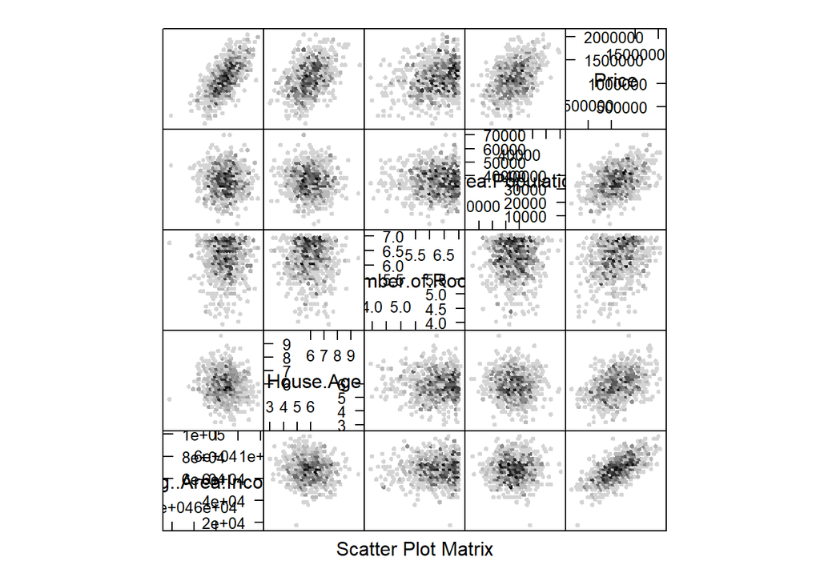

```r
hexplom(~ house.df.2br, data=house.df.2br)
```

#### Testing means between two different groups

Let see how the prices vary between houses with different numbers of bedrooms.

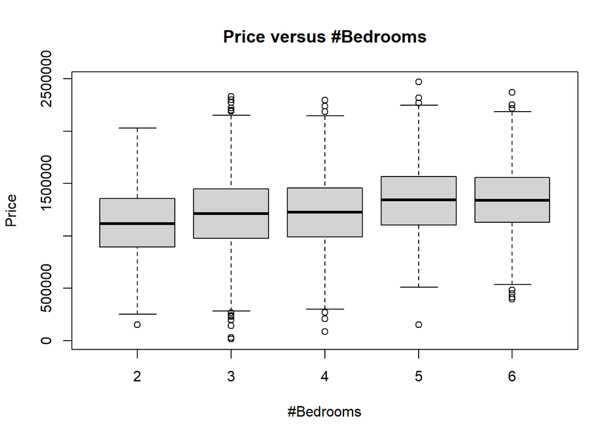

```r
house.df$Number.of.Bedrooms = factor(house.df$Number.of.Bedrooms)
#par(mfrow=c(1,1))
boxplot(Price~Number.of.Bedrooms,data = house.df,  main="Price versus #Bedrooms",
        xlab="#Bedrooms", ylab="Price")
```

Visually, the prices slightly differ between 2Br and 3Br houses, and do not differ between 5Br and 6Br houses. Now let us try simple two-sample t-tests:

```r
table(house.df$Number.of.Bedrooms)
```

```
##
##    2    3    4    5    6
##  751 1364 1334  547  552
```

```r
t.test(house.df$Price[house.df$Number.of.Bedrooms==2],house.df$Price[house.df$Number.of.Bedrooms==3])
```

```
##
##  Welch Two Sample t-test
##
## data:  house.df$Price[house.df$Number.of.Bedrooms == 2] and house.df$Price[house.df$Number.of.Bedrooms == 3]
## t = -5.8715, df = 1651.2, p-value = 5.21e-09
## alternative hypothesis: true difference in means is not equal to 0
## 95 percent confidence interval:
##  -123081.45  -61441.03
## sample estimates:
## mean of x mean of y
##   1125754   1218016
```

```r
t.test(house.df$Price[house.df$Number.of.Bedrooms==5],house.df$Price[house.df$Number.of.Bedrooms==6])
```

```
##
##  Welch Two Sample t-test
##
## data:  house.df$Price[house.df$Number.of.Bedrooms == 5] and house.df$Price[house.df$Number.of.Bedrooms == 6]
## t = -0.084725, df = 1088.5, p-value = 0.9325
## alternative hypothesis: true difference in means is not equal to 0
## 95 percent confidence interval:
##  -41666.05  38216.72
## sample estimates:
## mean of x mean of y
##   1339823   1341548
```

Confirms what we saw visually

#### Linear regression modeling

The linear model is arguably the most widely used statistical model, has a place in nearly every application domain of statistics

Given response Y and predictors X1,…,Xp, in a linear regression model, we posit:

$Y=\beta_0+\beta_1 X_1+\ldots +\beta_p X_p+\epsilon$,where $\epsilon\sim N(0,\sigma^2)$

Goal is to estimate parameters, also called coefficients $\beta_0$,$\beta_1$,..,$\beta_p$.

Fitting a linear regression model with lm()

We can use lm() to fit a linear regression model. The first argument is a formula, of the form Y ~ X1 + X2 + … + Xp, where Y is the response and X1, ???, Xp are the predictors. These refer to column names of variables in a data frame, that we pass in through the data argument

E.g., for the house data, to regress the response variable Price onto the predictors variables Avg..Area.Income, House.Age, Area.Population, Number.of.Rooms :

```r
house.lm = lm(Price ~  Avg..Area.Income + House.Age +  Area.Population+  Number.of.Rooms , data=house.df)
class(house.lm) # A class or R object is usually a specialized "list"
```

```
## [1] "lm"
```

```r
names(house.lm) # Here are its components
```

```
##  [1] "coefficients"  "residuals"     "effects"       "rank"
##  [5] "fitted.values" "assign"        "qr"            "df.residual"
##  [9] "xlevels"       "call"          "terms"         "model"
```

```r
house.lm # It has a special way of printing
```

```
##
## Call:
## lm(formula = Price ~ Avg..Area.Income + House.Age + Area.Population +
##     Number.of.Rooms, data = house.df)
##
## Coefficients:
##      (Intercept)  Avg..Area.Income         House.Age   Area.Population
##       -2.640e+06         2.161e+01         1.654e+05         1.519e+01
##  Number.of.Rooms
##        1.220e+05
```

#### Utility functions

Linear models in R come with a bunch of utility functions, such as coef(), fitted(), residuals(), summary(), plot(), predict(), for retrieving coefficients, fitted values, residuals, producing summaries, producing diagnostic plots, making predictions, respectively

These tasks can also be done manually, by extracting at the components of the returned object from lm(), and manipulating them appropriately. But this is discouraged, because: The manual strategy is more tedious and error prone

Once you master the utility functions, you will be able to retrieve coefficients, fitted values, make predictions, etc., in the same way for model objects returned by glm(), gam(), and many others Retrieving estimated coefficients with coef() So, what were the regression coefficients that we estimated? Use the coef() function, to retrieve them:

```r
house.coef = coef(house.lm) # Vector of 3 coefficients
house.coef
```

```
##      (Intercept) Avg..Area.Income        House.Age  Area.Population
##    -2.639656e+06     2.161438e+01     1.653717e+05     1.518536e+01
##  Number.of.Rooms
##     1.219736e+05
```

What does a linear regression coefficient mean, i.e., how do you interpret it? Displaying an overview with summary() The function summary() gives us a nice summary of the linear model we fit:

```r
summary(house.lm) # Special way of summarizing
```

```
##
## Call:
## lm(formula = Price ~ Avg..Area.Income + House.Age + Area.Population +
##     Number.of.Rooms, data = house.df)
##
## Residuals:
##     Min      1Q  Median      3Q     Max
## -339350  -70321    -126   69246  347378
##
## Coefficients:
##                    Estimate Std. Error t value Pr(>|t|)
## (Intercept)      -2.640e+06  1.790e+04 -147.45   <2e-16 ***
## Avg..Area.Income  2.161e+01  1.403e-01  154.04   <2e-16 ***
## House.Age         1.654e+05  1.513e+03  109.27   <2e-16 ***
## Area.Population   1.519e+01  1.513e-01  100.35   <2e-16 ***
## Number.of.Rooms   1.220e+05  1.490e+03   81.88   <2e-16 ***
## ---
## Signif. codes:  0 '***' 0.001 '**' 0.01 '*' 0.05 '.' 0.1 ' ' 1
##
## Residual standard error: 101100 on 4543 degrees of freedom
## Multiple R-squared:  0.9188, Adjusted R-squared:  0.9187
## F-statistic: 1.284e+04 on 4 and 4543 DF,  p-value: < 2.2e-16
```

This tells us:

The quantiles of the residuals: ideally, this is a perfect normal distribution

The coefficient estimates

Their standard errors

P-values for their individual significances

(Adjusted) R-squared value: how much variability is explained by the model?

F-statistic for the significance of the overall model

Running diagnostics with plot()

We can use the plot() function to run a series of diagnostic tests for our regression:

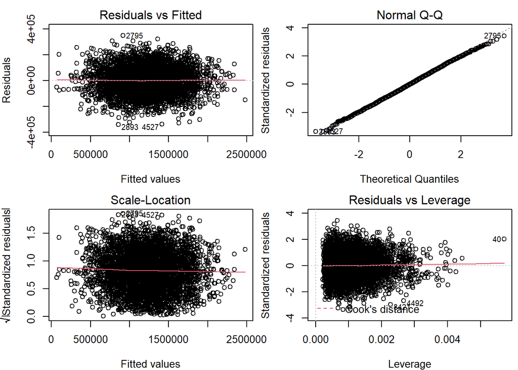

```r
par(mfrow=c(2,2),mar=c(4,4,2,0.5))
plot(house.lm) # Special way of plotting
```

The results are pretty good: why? Residuals vs Fitted plot: points appear randomly scattered, no particular pattern

Normal Q-Q plot: points are mostly along the 45 degree line, so residuals look close to a normal distribution

Scale-Location and Residuals vs Leverage plots: no obvious groups, no points are too far from the center

There is a science (and an art?) to interpreting these; you will learn a lot more in the regression course, and the other more advanced statistical courses.

There are six types of plots that you can choose from using plot(lm). If you need other types of plots, you need to generate them manually. E.g., fitted vs actual.

Retrieving fitted values with fitted() What does our model predict for the price, and how do these compare to the actual? Use the fitted() function, then plot the actual values versus the fitted ones:

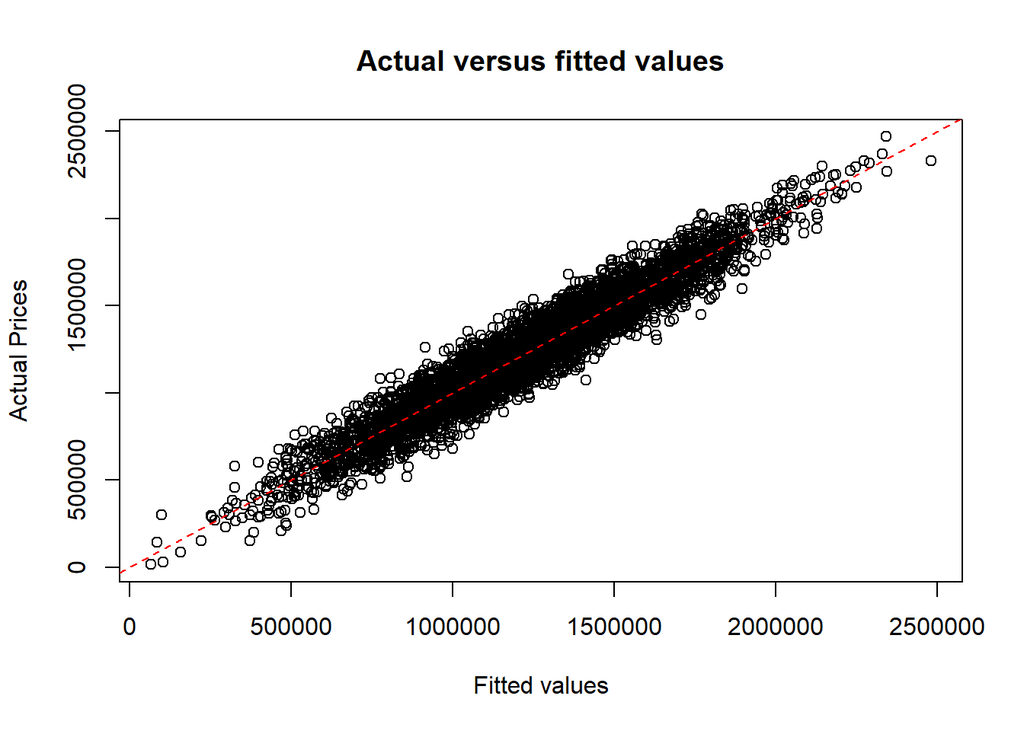

```r
house.fits = fitted(house.lm)
plot(house.fits, house.df$Price, main="Actual versus fitted values",
     xlab="Fitted values", ylab="Actual Prices")
abline(a=0, b=1, lty=2, col="red")
```

Making predictions with predict()

Suppose you are considering buying a four year old house with 7 or 15 rooms in Durham. For Durham, the average income is 71190, and the population is 14638. What does your linear model tells you to pay? What problem does your prediction have?

```r
house.new = data.frame(Avg..Area.Income=rep(71190,2),Area.Population=rep(14638,2),Number.of.Rooms=c(7,15),House.Age=rep(4,2)) # Must set up a new data frame
house.pred = predict(house.lm, newdata=house.new) # Now call predict with new df
house.pred
```

```
##         1         2
##  636657.6 1612446.6
```

Here are some handy shortcuts, for fitting linear models with lm() (there are also many others): No intercept (no $\beta_0$ in the mathematical model): use 0 + on the right-hand side of the formula, as in:

```r
summary(lm(Price ~ 0 + Avg..Area.Income + House.Age +  Area.Population+  Number.of.Rooms, data=house.df))
```

```
##
## Call:
## lm(formula = Price ~ 0 + Avg..Area.Income + House.Age + Area.Population +
##     Number.of.Rooms, data = house.df)
##
## Residuals:
##     Min      1Q  Median      3Q     Max
## -870619 -181834  -16615  147689  913375
##
## Coefficients:
##                    Estimate Std. Error t value Pr(>|t|)
## Avg..Area.Income    10.2539     0.2821  36.354   <2e-16 ***
## House.Age        50653.8153  3122.2381  16.224   <2e-16 ***
## Area.Population      8.0519     0.3448  23.350   <2e-16 ***
## Number.of.Rooms  -6488.9266  2905.9581  -2.233   0.0256 *
## ---
## Signif. codes:  0 '***' 0.001 '**' 0.01 '*' 0.05 '.' 0.1 ' ' 1
##
## Residual standard error: 243200 on 4544 degrees of freedom
## Multiple R-squared:  0.9642, Adjusted R-squared:  0.9641
## F-statistic: 3.056e+04 on 4 and 4544 DF,  p-value: < 2.2e-16
```

Include all predictors: use . on the right-hand side of the formula, as in:

```r
summary(lm(Price ~ ., data=house.df))
```

```
##
## Call:
## lm(formula = Price ~ ., data = house.df)
##
## Residuals:
##     Min      1Q  Median      3Q     Max
## -336084  -70416    -408   68928  351833
##
## Coefficients:
##                       Estimate Std. Error  t value Pr(>|t|)
## (Intercept)         -2.640e+06  1.848e+04 -142.841   <2e-16 ***
## Avg..Area.Income     2.161e+01  1.403e-01  153.990   <2e-16 ***
## House.Age            1.654e+05  1.513e+03  109.292   <2e-16 ***
## Number.of.Rooms      1.218e+05  1.732e+03   70.316   <2e-16 ***
## Number.of.Bedrooms3 -2.992e+03  4.747e+03   -0.630    0.528
## Number.of.Bedrooms4  7.306e+03  4.753e+03    1.537    0.124
## Number.of.Bedrooms5  3.078e+03  6.312e+03    0.488    0.626
## Number.of.Bedrooms6  5.895e+02  6.303e+03    0.094    0.925
## Area.Population      1.519e+01  1.513e-01  100.361   <2e-16 ***
## ---
## Signif. codes:  0 '***' 0.001 '**' 0.01 '*' 0.05 '.' 0.1 ' ' 1
##
## Residual standard error: 101100 on 4539 degrees of freedom
## Multiple R-squared:  0.9189, Adjusted R-squared:  0.9187
## F-statistic:  6428 on 8 and 4539 DF,  p-value: < 2.2e-16
```

Include interaction terms: use : between two predictors of interest, to include the interaction between them as a predictor, as in:

```r
summary(lm(Price ~ Avg..Area.Income + House.Age +  Area.Population+  Number.of.Rooms+ House.Age:Area.Population, data=house.df))
```

```
##
## Call:
## lm(formula = Price ~ Avg..Area.Income + House.Age + Area.Population +
##     Number.of.Rooms + House.Age:Area.Population, data = house.df)
##
## Residuals:
##     Min      1Q  Median      3Q     Max
## -337414  -70451     -10   69031  347586
##
## Coefficients:
##                             Estimate Std. Error t value Pr(>|t|)
## (Intercept)               -2.682e+06  3.664e+04  -73.20   <2e-16 ***
## Avg..Area.Income           2.161e+01  1.403e-01  154.02   <2e-16 ***
## House.Age                  1.725e+05  5.580e+03   30.92   <2e-16 ***
## Area.Population            1.636e+01  8.986e-01   18.21   <2e-16 ***
## Number.of.Rooms            1.220e+05  1.490e+03   81.89   <2e-16 ***
## House.Age:Area.Population -1.971e-01  1.482e-01   -1.33    0.184
## ---
## Signif. codes:  0 '***' 0.001 '**' 0.01 '*' 0.05 '.' 0.1 ' ' 1
##
## Residual standard error: 101100 on 4542 degrees of freedom
## Multiple R-squared:  0.9188, Adjusted R-squared:  0.9187
## F-statistic: 1.028e+04 on 5 and 4542 DF,  p-value: < 2.2e-16
```

#### Practice

1. Read the car medical charge dataset from https://raw.githubusercontent.com/stedy/Machine-Learning-with-R-datasets/master/insurance.csv Let us call it insurance.df. You can read https://www.kaggle.com/mirichoi0218/insurance to learn more about the dataset. The goal is to predict the medical cost billed by the health insurance. Check the data type of each column of insurance.df
2. To investigate the marginal distribution of each variable, plot the histogram for each numeric variables, and barplot for each categorical variable in the datset. For the latter, you will need R functions barplot() and table() Will you recommend any transformation of any of the numeric variables.
3. To investigate the association between the medical charges and each of the other variables, draw a scatter plot using “charges” at y-axis, and each of the other numeric variable at x axis, and a side-by-side box plot of “charges” using each of the categorical variable as the grouping variable.
4. You can also calculate the marginal correlation of the charges and each of the other numeric variables. What will happen to the correlations if you take the log of the charges?
5. Test whether there is any difference in the average of the charges between smokers and non-smokers
6. Compute, using `lm()`, a linear regression model of the log of `charges` on the other variables. Save the results as `insurance.lm`. Using `coef()`, display the coefficients (intercept and slope).
7. Plot the diagnostic plots of insurance.lm. Do you think the fit is good?
8. Regardless how good you think the model fit is, predict the medical cost at the original scale for a 28 years-old male smoker with bmi=30, and no children living in southeast region.